# STAT40800 Midterm Assignment

## Exploratory data analysis of the Irish weather

### Author: Shubh Gaur(23200555)

```python
# Load in necessary packages
import numpy as np
import pandas as pd
import matplotlib.pyplot as plt
import seaborn as sns
```

1. Load in the weather.csv dataset into Python as a pandas DataFrame. Describe the data. How many years of recordings are included? What is the temporal resolution of the data? Which weather measurements are reported? (8 marks)

```python
df=pd.read_csv('weather_1819.csv',skiprows=11)
df.head()
```

|  | day | month | year | station | maxtp | mintp | rain | wdsp | hg | sun |
| --- | --- | --- | --- | --- | --- | --- | --- | --- | --- | --- |
| 0 | 1 | jan | 2018 | Dublin Airport | 7.5 | 3.2 | 0.6 | 18.5 | 41.0 | 2.7 |
| 1 | 2 | jan | 2018 | Dublin Airport | 11.1 | 3.4 | 8.4 | 17.0 | 54.0 | 0.8 |
| 2 | 3 | jan | 2018 | Dublin Airport | 8.1 | 4.6 | 1.3 | 23.8 | 51.0 | 0.9 |
| 3 | 4 | jan | 2018 | Dublin Airport | 9.3 | 3.4 | 10.7 | 14.6 | 48.0 | 1.3 |
| 4 | 5 | jan | 2018 | Dublin Airport | 6.7 | -1.0 | 0.0 | 6.6 | 16.0 | 3.3 |

```python
#Describing the data
df.describe()
```

|  | day | year | maxtp | mintp | rain | wdsp | hg | sun |
| --- | --- | --- | --- | --- | --- | --- | --- | --- |
| count | 2920.000000 | 2920.000000 | 2902.000000 | 2902.000000 | 2897.000000 | 2915.000000 | 2904.000000 | 2913.000000 |
| mean | 15.720548 | 2018.500000 | 13.283150 | 6.432977 | 3.063583 | 9.481475 | 25.443871 | 3.783797 |
| std | 8.797754 | 0.500086 | 5.146289 | 4.368755 | 5.053881 | 3.820605 | 9.278313 | 3.850012 |
| min | 1.000000 | 2018.000000 | -1.800000 | -7.000000 | 0.000000 | 2.300000 | 7.000000 | 0.000000 |
| 25% | 8.000000 | 2018.000000 | 9.500000 | 3.100000 | 0.000000 | 6.500000 | 19.000000 | 0.300000 |
| 50% | 16.000000 | 2018.500000 | 12.800000 | 6.400000 | 0.700000 | 8.900000 | 24.000000 | 2.600000 |
| 75% | 23.000000 | 2019.000000 | 17.100000 | 9.600000 | 4.000000 | 11.800000 | 30.000000 | 6.300000 |
| max | 31.000000 | 2019.000000 | 32.000000 | 18.900000 | 54.600000 | 28.500000 | 84.000000 | 15.900000 |

```python
#Finding no. of unique values for year column
df.year.unique()
```

```
array([2018, 2019])
```

As can be seen there are two unique values for the year column.Therefore, the dataset contains data for the span of two years i.e 2018 -> 2019

```python
#Finding no. of unique values for year column
print(df.month.unique())
print(df.day.unique())
```

```
['jan' 'feb' 'mar' 'apr' 'may' 'jun' 'jul' 'aug' 'sep' 'oct' 'nov' 'dec']
[ 1  2  3  4  5  6  7  8  9 10 11 12 13 14 15 16 17 18 19 20 21 22 23 24
 25 26 27 28 29 30 31]
```

```python
#changing month names

# importing library for modifying month names
import calendar

#dictionary by month order for sorting
months={'jan':1,'feb':2,'mar':3,'apr':4,'may':5,'jun':6,'jul':7,
        'aug':8,'sep':9,'oct':10,'nov':11,'dec':12}

#creating a new column by mapping it to the dictiionary
df['month_index']=df.month.map(months)

#changing month names
df['month']=df.month_index.apply(lambda a: calendar.month_name[a])

#sorting by month_index
df=df.sort_values('month_index').reset_index(drop=True)
df.head()
```

|  | day | month | year | station | maxtp | mintp | rain | wdsp | hg | sun | month_index |
| --- | --- | --- | --- | --- | --- | --- | --- | --- | --- | --- | --- |
| 0 | 1 | January | 2018 | Dublin Airport | 7.5 | 3.2 | 0.6 | 18.5 | 41.0 | 2.7 | 1 |
| 1 | 14 | January | 2018 | Knock Airport | 9.3 | 3.8 | 6.6 | 14.1 | 38.0 | 0.1 | 1 |
| 2 | 15 | January | 2018 | Knock Airport | 8.3 | 1.0 | 9.9 | 14.8 | 36.0 | 2.2 | 1 |
| 3 | 16 | January | 2018 | Knock Airport | 2.6 | -0.8 | 8.6 | 18.5 | 47.0 | 0.2 | 1 |
| 4 | 17 | January | 2018 | Knock Airport | 8.8 | 0.7 | 18.8 | 16.8 | 50.0 | 0.1 | 1 |

The temporal resolution for data is **daily** as can be identified by seeing the unique values of columns: month and day which contain all the possible values for the respective columns.

```python
df.columns
#note: month_index is a newly added column
```

```
Index(['day', 'month', 'year', 'station', 'maxtp', 'mintp', 'rain', 'wdsp',
       'hg', 'sun', 'month_index'],
      dtype='object')
```

The reported weather measurements in the dataset are as follows:-  
**maxtp**: Maximum Air Temperature (C)  
**mintp**: Minimum Air Temperature (C)  
**rain**: Precipitation Amount (mm)  
**wdsp**: Mean Wind Speed (knot)  
**hg**: Highest Gust (knot)  
**sun**: Sunshine duration (hours)

2. Determine how many missing values there are in each column of the dataset. Can you think of a reason why these values are missing? Discuss different strategies for filling the missing values, highlighting the advantages and disadvantages of each strategy, in the context of this dataset. (8 marks)

   **Note:** You do not need to implement any of your suggested strategies.

```python
#finding null values for each column in the dataset
#discuss
df.isnull().sum()
```

```
day             0
month           0
year            0
station         0
maxtp          18
mintp          18
rain           23
wdsp            5
hg             16
sun             7
month_index     0
dtype: int64
```

There can be many reasons for the missing data in context of the current dataset which are mentioned below:

- Mistakes in data preprocessing.
- Malfunctions and calibration issues with different sensors.
- Transmission problems.
- Extreme conditions such as storm, heavy snowfall, etc. can sometimes interfere with weather station's equipment.
- Maintenance activities at weather stations contribute to service downtime for the affected period.

The different strategies for filling NA values:

- The data can be grouped based on location and month and the mean weather measurement for the particular month can be used to fill the missing values.

Pros: Higher Accuracy  
Cons: Higher complexity in filling NA values

- The missing data can either be frontfilled or backfilled in all the columns which may or may not work depending on whether the data is ordered based on location and months.

Pros: Lower complexity in filling NA values  
Cons: Accuracy may be compromised

3. Write code to answer the following questions: (15 marks)
   1. At what station and on what date was the highest wind speed recorded?
   2. At what station and on what date was the highest maximum air temperature recorded?
   3. At what station and on what date was the largest amount of rain recorded?

#### A

```python
#finding row index which has the maximum: windspeed
maxIndex=df.wdsp.idxmax()
print('The highest windspeed with magnitude of',
      df.loc[maxIndex,'wdsp'],'knots was recorded on',
      str(df.loc[maxIndex,'day']),df.loc[maxIndex,'month'],
      (df.loc[maxIndex,'year']),'at',df.loc[maxIndex,'station']
      +'.')

df.loc[maxIndex]
```

```
The highest windspeed with magnitude of 28.5 knots was recorded on 2 March 2018 at Dublin Airport.
```

```
day                         2
month                   March
year                     2018
station        Dublin Airport
maxtp                    -0.2
mintp                    -1.2
rain                      5.6
wdsp                     28.5
hg                       50.0
sun                       0.0
month_index                 3
Name: 678, dtype: object
```

#### B

```python
#finding row index which has the maximum: maxtp
maxIndex=df.maxtp.idxmax()
print('The highest air temperature with magnitude of',
      str(df.loc[maxIndex,'maxtp'])+'°C','was recorded on',
      str(df.loc[maxIndex,'day']),df.loc[maxIndex,'month'],
      str(df.loc[maxIndex,'year']),
      'at',df.loc[maxIndex,'station']
      +'.')

df.loc[maxIndex]
```

```
The highest air temperature with magnitude of 32.0°C was recorded on 28 June 2018 at Shannon Airport.
```

```
day                         28
month                     June
year                      2018
station        Shannon Airport
maxtp                     32.0
mintp                     12.4
rain                       0.0
wdsp                       4.9
hg                        20.0
sun                       15.6
month_index                  6
Name: 1391, dtype: object
```

#### C

```python
#finding row index which has the maximum windspeed
maxIndex=df.rain.idxmax()
print('The largest rainfall with magnitude of',
      str(df.loc[maxIndex,'rain'])+'mm','was recorded on',
      str(df.loc[maxIndex,'day']),df.loc[maxIndex,'month'],
      str(df.loc[maxIndex,'year']),'at',df.loc[maxIndex,'station']
      +'.')

df.loc[maxIndex]
```

```
The largest rainfall with magnitude of 54.6mm was recorded on 15 April 2019 at Cork Airport.
```

```
day                      15
month                 April
year                   2019
station        Cork Airport
maxtp                   8.3
mintp                   5.2
rain                   54.6
wdsp                   19.6
hg                     45.0
sun                     0.0
month_index               4
Name: 920, dtype: object
```

4. Create a numerical summary (mean, standard deviation, minimum, maximum, etc.) for each of the weather measurements. Discuss and interpret your results. (8 marks)

#### Numerical Summary for maxtp

```python
print('Number of rows in the dataset:-',df.shape[0])
```

```
Number of rows in the dataset:- 2920
```

```python
df.maxtp.describe()
```

```
count    2902.000000
mean       13.283150
std         5.146289
min        -1.800000
25%         9.500000
50%        12.800000
75%        17.100000
max        32.000000
Name: maxtp, dtype: float64
```

According to the numerical summary of maximum temperature values, we interpret:

- There are 2902 datapoints for the maximum temperature values in a day.
- Average maximum temperature for the day throughout the 2 years timeframe is approximately 13.2°C.
- There is some variation in data as can be seen from the standard deviation value which is approximately 5.14°C and it suggests that daily maximum temperatures highly vary which is justified by Ireland's variable climates.
- The minimum value amongst maximum temperature values in a day is -1.8°C.
- The maximum value amongst maximum temperature values in a day is 32°C.
- The median temperature amongst maximum temperature values in a day is 12.8°C.

#### Numerical Summary for mintp

```python
df.mintp.describe()
```

```
count    2902.000000
mean        6.432977
std         4.368755
min        -7.000000
25%         3.100000
50%         6.400000
75%         9.600000
max        18.900000
Name: mintp, dtype: float64
```

#### Numerical Summary for rain

```python
df.rain.describe()
```

```
count    2897.000000
mean        3.063583
std         5.053881
min         0.000000
25%         0.000000
50%         0.700000
75%         4.000000
max        54.600000
Name: rain, dtype: float64
```

According to the numerical summary of rainfall values, we interpret:

#### Numerical Summary for wdsp

```python
df.wdsp.describe()
```

```
count    2915.000000
mean        9.481475
std         3.820605
min         2.300000
25%         6.500000
50%         8.900000
75%        11.800000
max        28.500000
Name: wdsp, dtype: float64
```

According to the numerical summary of windspeed values, we interpret:

- There are 2915 datapoints for the windspeed values in a day.
- Average windspeed for the day throughout the 2 years timeframe is approximately 9.4 knots.
- There is some variation in data as can be seen from the standard deviation value which is approximately 3.82 knots and this suggests that windspeeds may vary a noticeable amount from the mean which may be due to the fact that Ireland exhibits changing wind patterns as its climate is influenced by Atlantic ocean.
- The minimum value amongst windspeed values in a day is 2.3 knots.
- The maximum value amongst windspeed values in a day is 28.5 knots.
- The median windspeed amongst windspeed values in a day is 8.9 knots.

#### Numerical Summary for hg

```python
df.hg.describe()
```

```
count    2904.000000
mean       25.443871
std         9.278313
min         7.000000
25%        19.000000
50%        24.000000
75%        30.000000
max        84.000000
Name: hg, dtype: float64
```

According to the numerical summary of highest gust values, we interpret:

- There are 2904 datapoints for the highest gust values in a day.
- Average highest gust for the day throughout the 2 years timeframe is approximately 25.44 knots.
- There is some variation in data as can be seen from the standard deviation value which is approximately 9.27 knots and it suggests that wind gusts can vary significantly from day to day and this may be due to the fact that wind gusts are highly influenced by ocean currents and Ireland's close proximity to Atlantic ocean seems to do the job well.
- The minimum value amongst highest gust values in a day is 7 knots.
- The maximum value amongst highest gust values in a day is 84 knots.
- The median value amongst highest gust values in a day is 24 knots.

#### Numerical Summary for sun

```python
df.sun.describe()
```

```
count    2913.000000
mean        3.783797
std         3.850012
min         0.000000
25%         0.300000
50%         2.600000
75%         6.300000
max        15.900000
Name: sun, dtype: float64
```

#### Graphical Summary for maxtp

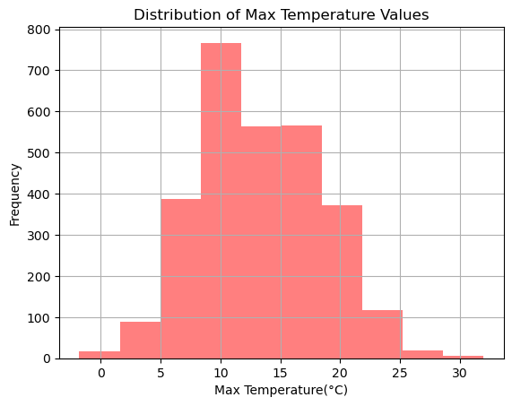

```python
df.maxtp.hist(color='r',alpha=0.5)
plt.title('Distribution of Max Temperature Values')
plt.xlabel('Max Temperature(°C)')
plt.ylabel('Frequency')
plt.show()
```

#### Graphical Summary for mintp

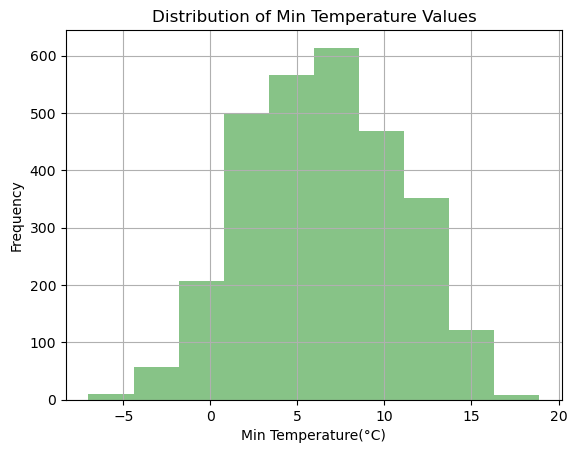

```python
df.mintp.hist(color='g',alpha=0.47)
plt.title('Distribution of Min Temperature Values')
plt.xlabel('Min Temperature(°C)')
plt.ylabel('Frequency')
plt.show()
```

- The minimum value amongst minimum temperature values in a day is a bit lesser than -5°C which is consistent with the minimum value in numerical summary i.e -7°C.
- The maximum value amongst minimum temperature values in a day is between 15°C and 20°C which is consistent with the maximum value in numerical summary i.e 18.9°C.
- The median value for minimum temperature in a day as can be seen from the histogram is between 5°C and 10°C amongst minimum temperature values in a day as some temperature value between the specified boundaries will divide the data distribution into two equal halves which is consistent with the numerical summary with median min temperature value of 6.4°C.

#### Graphical Summary for rain

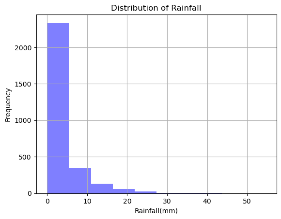

```python
df.rain.hist(color='b',alpha=0.5)
plt.title('Distribution of Rainfall')
plt.xlabel('Rainfall(mm)')
plt.ylabel('Frequency')
plt.show()
```

- The minimum value amongst rainfall values in a day is 0 mm which is consistent with the minimum value in numerical summary.
- The maximum value amongst rainfall values in a day is greater than 50 mm which is consistent with the maximum value in numerical summary i.e 54.6 mm.
- The median value for rainfall in a day as can be seen from the histogram is between 0mm and 5mm amongst rainfall values in a day as some rainfall value between the specified boundaries will divide the data distribution into two equal halves which is consistent with the numerical summary with median rainfall value of 0.7 mm.

#### Graphical Summary for wdsp

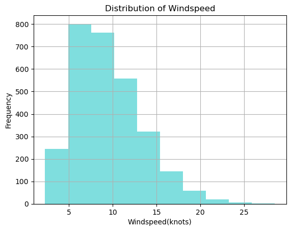

```python
df.wdsp.hist(color='c',alpha=0.5)
plt.title('Distribution of Windspeed')
plt.xlabel('Windspeed(knots)')
plt.ylabel('Frequency')
plt.show()
```

- The minimum value amongst windspeed values in a day is between 0 and 5 knots which is consistent with the minimum value in numerical summary i.e 2.3 knots .
- The maximum value amongst windspeed values in a day is greater than 25 knots which is consistent with the maximum value in numerical summary i.e 28.5 knots.
- The median value for windspeed in a day as can be seen from the histogram is between 5 and 10 knots amongst windspeed values in a day as some windspeed value between the specified boundaries will divide the data distribution into two equal halves which is consistent with the numerical summary with median windspeed value of 8.9 knots.

#### Graphical Summary for hg

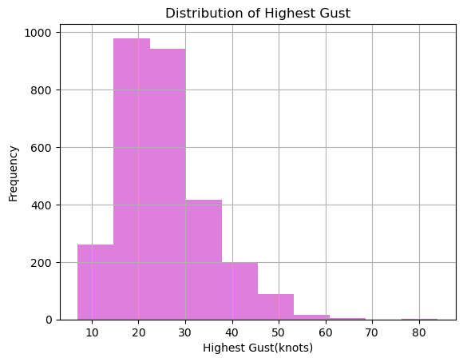

```python
df.hg.hist(color='m',alpha=0.5)
plt.title('Distribution of Highest Gust')
plt.xlabel('Highest Gust(knots)')
plt.ylabel('Frequency')
plt.show()
```

- The minimum value amongst highest gust values in a day is lesser than 10 knots which is consistent with the minimum value in numerical summary i.e 7 knots .
- The maximum value amongst highest gust values in a day is greater than 80 knots which is consistent with the maximum value in numerical summary i.e 84 knots.
- The median value for highest gust in a day as can be seen from the histogram is between 20 and 30 knots amongst highest gust values in a day as some highest gust value between the specified boundaries will divide the data distribution into two equal halves which is consistent with the numerical summary with median highest gust value of 24 knots.

#### Graphical Summary for sun

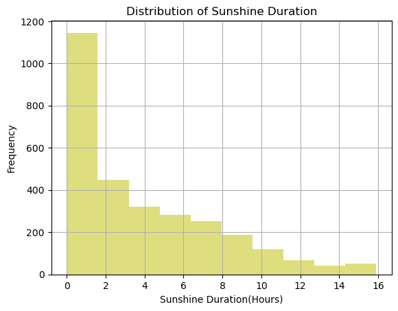

```python
df.sun.hist(color='y',alpha=0.5)
plt.title('Distribution of Sunshine Duration')
plt.xlabel('Sunshine Duration(Hours)')
plt.ylabel('Frequency')
plt.show()
```

- The minimum value amongst sunlight duration values in a day is 0 hours which is consistent with the minimum value in numerical summary.
- The maximum value amongst sunlight duration values in a day is between 14 and 16 hours which is consistent with the maximum value in numerical summary i.e 15.9 hours.
- The median value for sunlight duration in a day as can be seen from the histogram is between 2 and 4 hours amongst sunlight duration values in a day as some sunlight duration value between the specified boundaries will divide the data distribution into two equal halves which is consistent with the numerical summary with median sunlight duration value of 2.6 hours.
6. Produce a scatter plot of the mean wind speed versus the highest gust and colour your points based on month. Interpret your plot. (8 marks)

```python
df
```

|  | day | month | year | station | maxtp | mintp | rain | wdsp | hg | sun | month_index |
| --- | --- | --- | --- | --- | --- | --- | --- | --- | --- | --- | --- |
| 0 | 1 | January | 2018 | Dublin Airport | 7.5 | 3.2 | 0.6 | 18.5 | 41.0 | 2.7 | 1 |
| 1 | 14 | January | 2018 | Knock Airport | 9.3 | 3.8 | 6.6 | 14.1 | 38.0 | 0.1 | 1 |
| 2 | 15 | January | 2018 | Knock Airport | 8.3 | 1.0 | 9.9 | 14.8 | 36.0 | 2.2 | 1 |
| 3 | 16 | January | 2018 | Knock Airport | 2.6 | -0.8 | 8.6 | 18.5 | 47.0 | 0.2 | 1 |
| 4 | 17 | January | 2018 | Knock Airport | 8.8 | 0.7 | 18.8 | 16.8 | 50.0 | 0.1 | 1 |
| ... | ... | ... | ... | ... | ... | ... | ... | ... | ... | ... | ... |
| 2915 | 15 | December | 2018 | Cork Airport | 11.9 | 2.3 | 19.5 | 15.5 | 50.0 | 0.0 | 12 |
| 2916 | 14 | December | 2018 | Cork Airport | 10.4 | 7.1 | 16.1 | 15.1 | 32.0 | 0.3 | 12 |
| 2917 | 13 | December | 2018 | Cork Airport | 8.8 | 7.1 | 18.6 | 20.0 | 45.0 | 0.0 | 12 |
| 2918 | 24 | December | 2018 | Cork Airport | 10.5 | 7.7 | 4.2 | 9.2 | 23.0 | 0.0 | 12 |
| 2919 | 31 | December | 2019 | Knock Airport | 6.0 | 1.3 | 0.0 | 7.1 | 18.0 | 2.1 | 12 |

2920 rows × 11 columns

```python
# Group by 'Category' and calculate the means of 'wdsp' and 'hg'
grouped_means = df.groupby('month')[['wdsp', 'hg','month_index']].mean().sort_index()

#changing month names
grouped_means['month']=grouped_means.month_index.apply(lambda a: calendar.month_name[int(a)])

#sorting by month_index
grouped_means=grouped_means.sort_values('month_index').drop(columns=['month_index']).reset_index(drop=True)
grouped_means
```

|  | wdsp | hg | month |
| --- | --- | --- | --- |
| 0 | 10.734274 | 29.641129 | January |
| 1 | 10.974107 | 28.919643 | February |
| 2 | 10.684274 | 27.971660 | March |
| 3 | 10.241250 | 26.337500 | April |
| 4 | 8.230769 | 21.570850 | May |
| 5 | 8.154583 | 21.812500 | June |
| 6 | 7.712955 | 20.338710 | July |
| 7 | 8.898790 | 23.769231 | August |
| 8 | 8.887500 | 24.527426 | September |
| 9 | 9.142276 | 24.609053 | October |
| 10 | 9.967083 | 27.037657 | November |
| 11 | 10.260729 | 29.086066 | December |

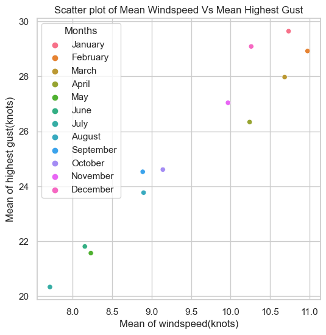

```python
# Create a scatter plot using Seaborn
sns.set(style="whitegrid")

plt.figure(figsize=(6,6))
sns.scatterplot(data=grouped_means, x='wdsp', y='hg',
                hue='month', legend='full')

# Add a legend
plt.legend(title='Months')

plt.xlabel('Mean of windspeed(knots)')
plt.ylabel('Mean of highest gust(knots)')
plt.title('Scatter plot of Mean Windspeed Vs Mean Highest Gust')
plt.grid(True)
plt.show()
```

As can be seen in the plot:-

- The mean windspeed and highest gust tend to follow a positive linear relationship.
- The mean windspeed as well as highest gust values are highest during winter months(November-March) and lowest in summer months(June-July)
- The windspeed and highest gust values are moderate in the period from August-October.
7. Compute the daily temperature range, and add this as an additional variable to your DataFrame. Print out the last 10 rows of your DataFrame to show that the column has been added correctly. (5 marks)

```python
# Adding temperature_range column to dataframe
df['temperature_range']=df.maxtp-df.mintp
df.tail(10)
```

|  | day | month | year | station | maxtp | mintp | rain | wdsp | hg | sun | month_index | temperature_range |
| --- | --- | --- | --- | --- | --- | --- | --- | --- | --- | --- | --- | --- |
| 2910 | 20 | December | 2018 | Cork Airport | 10.0 | 4.4 | 4.3 | 9.0 | 28.0 | 2.2 | 12 | 5.6 |
| 2911 | 19 | December | 2018 | Cork Airport | 7.9 | 3.1 | 6.7 | 11.8 | 27.0 | 1.6 | 12 | 4.8 |
| 2912 | 18 | December | 2018 | Cork Airport | 11.0 | 3.7 | 11.0 | NaN | 52.0 | 3.0 | 12 | 7.3 |
| 2913 | 17 | December | 2018 | Cork Airport | 11.1 | 2.3 | 1.8 | 16.5 | 44.0 | 0.0 | 12 | 8.8 |
| 2914 | 16 | December | 2018 | Cork Airport | 7.8 | 1.8 | 5.8 | 6.5 | 23.0 | 3.1 | 12 | 6.0 |
| 2915 | 15 | December | 2018 | Cork Airport | 11.9 | 2.3 | 19.5 | 15.5 | 50.0 | 0.0 | 12 | 9.6 |
| 2916 | 14 | December | 2018 | Cork Airport | 10.4 | 7.1 | 16.1 | 15.1 | 32.0 | 0.3 | 12 | 3.3 |
| 2917 | 13 | December | 2018 | Cork Airport | 8.8 | 7.1 | 18.6 | 20.0 | 45.0 | 0.0 | 12 | 1.7 |
| 2918 | 24 | December | 2018 | Cork Airport | 10.5 | 7.7 | 4.2 | 9.2 | 23.0 | 0.0 | 12 | 2.8 |
| 2919 | 31 | December | 2019 | Knock Airport | 6.0 | 1.3 | 0.0 | 7.1 | 18.0 | 2.1 | 12 | 4.7 |

8. Plot the daily temperature range versus the hours of sunlight per day, colouring the points based on month. Interpret your plot. (8 marks)

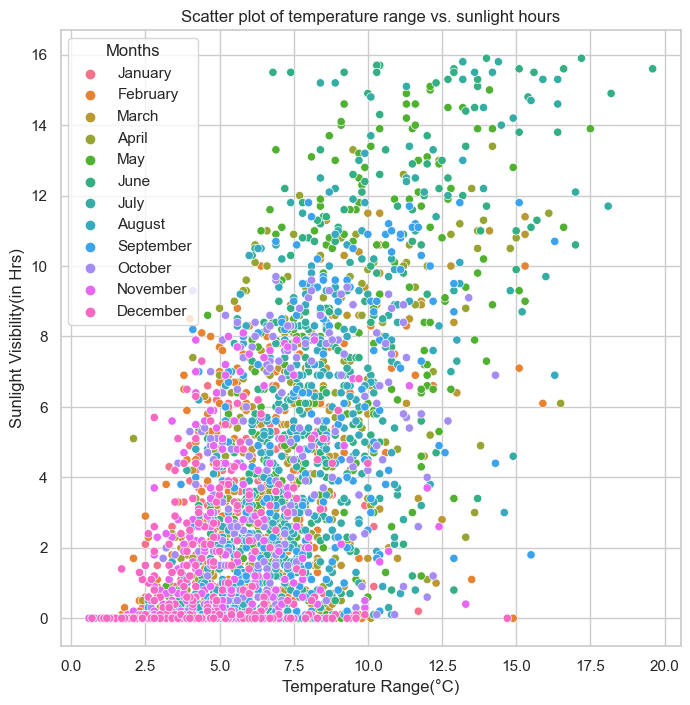

```python
#Plotting scatterplot b/w temperature range vs sunlight hours
sns.set(style="whitegrid")

plt.figure(figsize=(8,8))

sns.scatterplot(data=df, x='temperature_range', y='sun',
                hue='month', legend='full')


plt.xlabel('Temperature Range(°C)')
plt.ylabel('Sunlight Visibility(in Hrs)')
plt.title('Scatter plot of temperature range vs. sunlight hours')
plt.grid(True)
plt.legend(title='Months')
plt.show()
```

As can be seen in the plot:

- Sunlight visibility seems to be in a positive linear relationship with temperature range.
- Sunlight visibility is lowest in the winter months(November-February) and highest in summer months(May-July)
- Temperature Range or the variability of temperature over a day is highest in summer months and low-medium during winter months.
9. Perform a comparative analysis of the weather at Dublin Airport, Shannon Airport and Cork Airport. (20 marks)

   For full marks on this question you should create numerical and graphical summaries of the weather measurements at each weather station and discuss how the weather differs (or is similar) across these locations.

```python
#defining a dictionary to store dataframes using keys as station names
station_dict={'Dublin Airport': None,'Shannon Airport':None,
              'Cork Airport':None}

for i in station_dict:
    station_dict[i]=df[df.station==i]
```

```python
station_dict['Dublin Airport'].head()
```

|  | day | month | year | station | maxtp | mintp | rain | wdsp | hg | sun | month_index | temperature_range |
| --- | --- | --- | --- | --- | --- | --- | --- | --- | --- | --- | --- | --- |
| 0 | 1 | January | 2018 | Dublin Airport | 7.5 | 3.2 | 0.6 | 18.5 | 41.0 | 2.7 | 1 | 4.3 |
| 19 | 31 | January | 2019 | Dublin Airport | 4.0 | -5.8 | 4.0 | 11.7 | 31.0 | 0.0 | 1 | 9.8 |
| 20 | 30 | January | 2019 | Dublin Airport | 3.4 | -3.4 | 0.0 | 8.5 | 27.0 | 6.6 | 1 | 6.8 |
| 21 | 29 | January | 2019 | Dublin Airport | 3.9 | -0.4 | 3.0 | 11.7 | 28.0 | 3.7 | 1 | 4.3 |
| 22 | 28 | January | 2019 | Dublin Airport | 6.2 | -0.7 | 0.0 | 9.0 | 20.0 | 4.8 | 1 | 6.9 |

```python
station_dict['Shannon Airport'].head()
```

|  | day | month | year | station | maxtp | mintp | rain | wdsp | hg | sun | month_index | temperature_range |
| --- | --- | --- | --- | --- | --- | --- | --- | --- | --- | --- | --- | --- |
| 41 | 18 | January | 2019 | Shannon Airport | 10.1 | 4.2 | 3.6 | 8.0 | 27.0 | 5.1 | 1 | 5.9 |
| 110 | 30 | January | 2019 | Shannon Airport | 4.8 | -0.1 | 0.9 | 4.8 | 18.0 | 6.2 | 1 | 4.9 |
| 111 | 31 | January | 2019 | Shannon Airport | 5.6 | -0.3 | 10.0 | 13.4 | 32.0 | 1.0 | 1 | 5.9 |
| 133 | 29 | January | 2019 | Shannon Airport | 5.2 | 0.8 | 8.8 | 8.8 | 36.0 | 3.3 | 1 | 4.4 |
| 135 | 28 | January | 2019 | Shannon Airport | 7.3 | 3.3 | 2.5 | 8.1 | 28.0 | 3.9 | 1 | 4.0 |

```python
station_dict['Cork Airport'].head()
```

|  | day | month | year | station | maxtp | mintp | rain | wdsp | hg | sun | month_index | temperature_range |
| --- | --- | --- | --- | --- | --- | --- | --- | --- | --- | --- | --- | --- |
| 28 | 19 | January | 2019 | Cork Airport | 8.1 | 3.9 | 1.1 | 5.2 | 12.0 | 4.2 | 1 | 4.2 |
| 29 | 20 | January | 2019 | Cork Airport | 7.2 | 1.9 | 0.8 | 11.3 | 35.0 | 5.9 | 1 | 5.3 |
| 30 | 21 | January | 2019 | Cork Airport | 6.6 | -0.1 | 5.0 | 9.6 | 33.0 | 0.0 | 1 | 6.7 |
| 31 | 22 | January | 2019 | Cork Airport | 4.6 | -0.5 | 3.8 | 7.2 | 22.0 | 0.9 | 1 | 5.1 |
| 32 | 23 | January | 2019 | Cork Airport | 8.8 | 3.6 | 4.5 | 5.2 | 17.0 | 0.0 | 1 | 5.2 |

#### Numerical Summary for Dublin Airport

```python
#Fetching weather data for Dublin Airport
weather=station_dict['Dublin Airport'][['maxtp','mintp',
                                        'rain','wdsp','hg','sun']]
weather.describe()
```

|  | maxtp | mintp | rain | wdsp | hg | sun |
| --- | --- | --- | --- | --- | --- | --- |
| count | 730.000000 | 730.000000 | 726.000000 | 728.000000 | 728.000000 | 729.000000 |
| mean | 13.592603 | 5.724247 | 2.147383 | 9.542720 | 24.943681 | 4.046091 |
| std | 5.265505 | 4.488748 | 4.120571 | 3.829729 | 8.438033 | 3.952654 |
| min | -0.500000 | -5.800000 | 0.000000 | 3.000000 | 9.000000 | 0.000000 |
| 25% | 9.500000 | 2.400000 | 0.000000 | 6.700000 | 19.000000 | 0.600000 |
| 50% | 13.000000 | 5.600000 | 0.200000 | 8.800000 | 24.000000 | 2.900000 |
| 75% | 17.875000 | 8.900000 | 2.300000 | 11.500000 | 30.000000 | 6.600000 |
| max | 26.700000 | 17.800000 | 24.200000 | 28.500000 | 56.000000 | 15.900000 |

#### Distribution for various weather measurements at Dublin airport

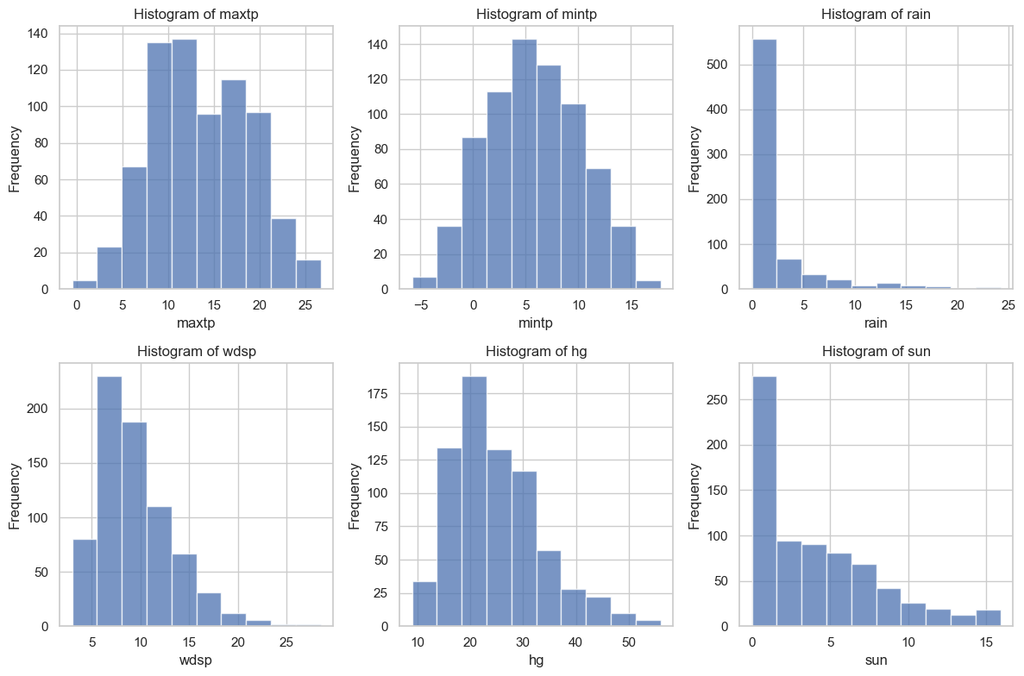

```python
fig, axes = plt.subplots(2, 3, figsize=(12, 8))

axes = axes.flatten()

for i, column in enumerate(weather.columns):
    ax = axes[i]
    ax.hist(weather[column],alpha=0.75)
    ax.set_title(f'Histogram of {column}')
    ax.set_xlabel(column)
    ax.set_ylabel('Frequency')

# Adjust layout
plt.tight_layout()

plt.show()
```

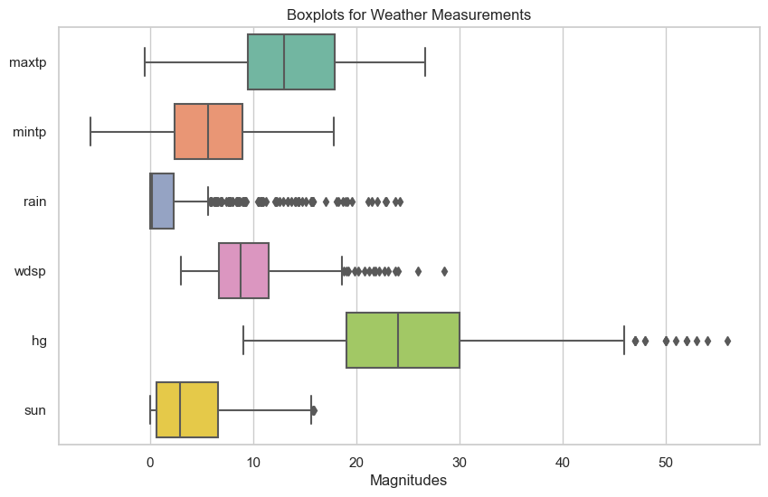

```python
sns.set(style="whitegrid")
plt.figure(figsize=(10, 6))
sns.boxplot(data=weather, orient="h",
            palette="Set2")#horizontally oriented

# Set labels for the boxplots
plt.xlabel("Magnitudes")
plt.title("Boxplots for Weather Measurements")

# Show the plot
plt.show()
```

#### Distribution for various weather measurements at Shannon airport

```python
#Fetching weather data for Shannon Airport
weather=station_dict['Shannon Airport'][['maxtp','mintp',
                                         'rain','wdsp','hg','sun']]
weather.describe()
```

|  | maxtp | mintp | rain | wdsp | hg | sun |
| --- | --- | --- | --- | --- | --- | --- |
| count | 723.000000 | 723.000000 | 721.000000 | 730.000000 | 724.000000 | 728.000000 |
| mean | 14.160028 | 7.267082 | 2.844383 | 9.264658 | 24.968232 | 3.900275 |
| std | 5.106169 | 4.442844 | 4.402685 | 4.013313 | 9.576674 | 3.883124 |
| min | 0.000000 | -5.000000 | 0.000000 | 2.300000 | 7.000000 | 0.000000 |
| 25% | 10.250000 | 3.850000 | 0.000000 | 6.100000 | 18.000000 | 0.500000 |
| 50% | 13.600000 | 7.200000 | 0.800000 | 8.750000 | 24.000000 | 2.700000 |
| 75% | 17.750000 | 10.850000 | 3.900000 | 11.700000 | 30.000000 | 6.500000 |
| max | 32.000000 | 18.900000 | 33.400000 | 25.200000 | 66.000000 | 15.600000 |

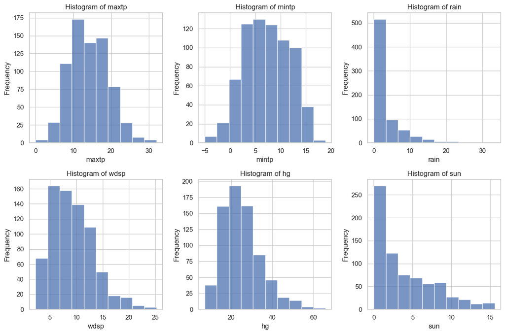

```python
fig, axes = plt.subplots(2, 3, figsize=(12, 8))


axes = axes.flatten()


for i, column in enumerate(weather.columns):
    ax = axes[i]
    ax.hist(weather[column],alpha=0.75)
    ax.set_title(f'Histogram of {column}')
    ax.set_xlabel(column)
    ax.set_ylabel('Frequency')

# Adjust layout
plt.tight_layout()

plt.show()
```

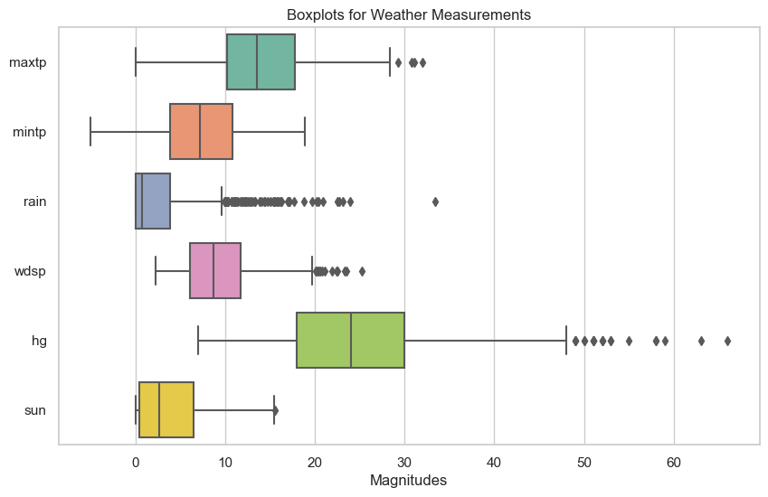

```python
sns.set(style="whitegrid")
plt.figure(figsize=(10, 6))
sns.boxplot(data=weather, orient="h",
            palette="Set2")#horizontally oriented

# Set labels for the boxplots
plt.xlabel("Magnitudes")
plt.title("Boxplots for Weather Measurements")

# Show the plot
plt.show()
```

#### Distribution for various weather measurements at Cork airport

```python
#Fetching weather data for Cork Airport
weather=station_dict['Cork Airport'][['maxtp','mintp','rain',
                                      'wdsp','hg','sun']]
weather.describe()
```

|  | maxtp | mintp | rain | wdsp | hg | sun |
| --- | --- | --- | --- | --- | --- | --- |
| count | 723.000000 | 723.000000 | 723.000000 | 728.000000 | 726.000000 | 727.000000 |
| mean | 13.262517 | 6.955325 | 3.470124 | 9.758516 | 25.976584 | 4.225860 |
| std | 4.894583 | 4.203288 | 6.137343 | 3.749587 | 9.336514 | 4.055068 |
| min | -1.800000 | -7.000000 | 0.000000 | 2.900000 | 10.000000 | 0.000000 |
| 25% | 9.750000 | 3.750000 | 0.000000 | 6.700000 | 19.000000 | 0.300000 |
| 50% | 12.500000 | 7.000000 | 0.700000 | 9.100000 | 24.500000 | 3.100000 |
| 75% | 17.100000 | 9.900000 | 4.250000 | 12.200000 | 32.000000 | 7.250000 |
| max | 26.700000 | 16.500000 | 54.600000 | 23.800000 | 63.000000 | 15.700000 |

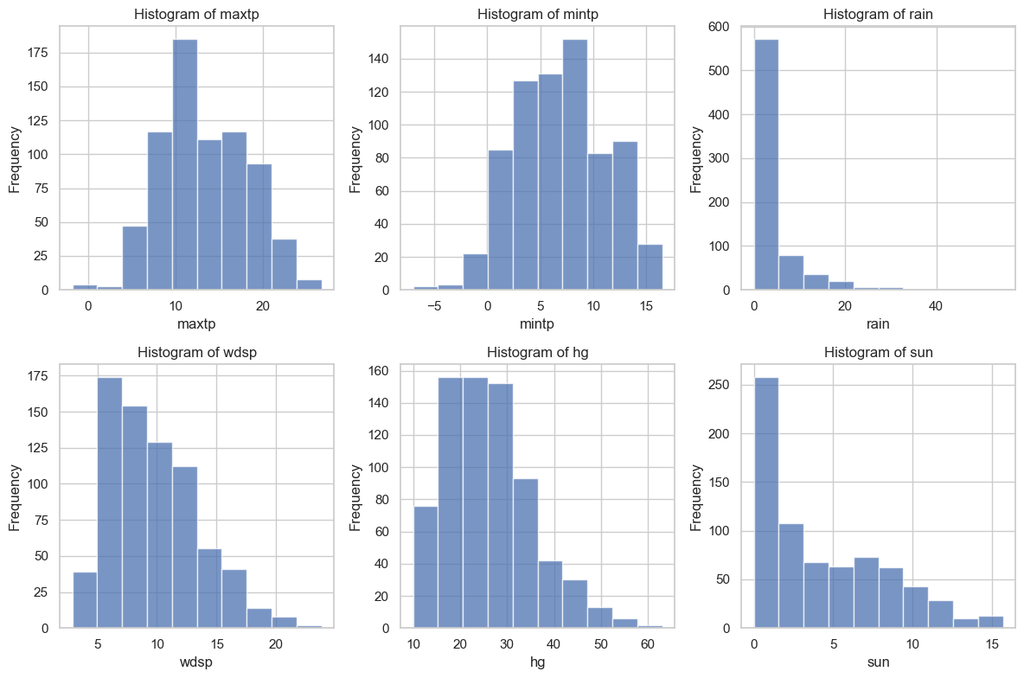

```python
fig, axes = plt.subplots(2, 3, figsize=(12, 8))

axes = axes.flatten()

for i, column in enumerate(weather.columns):
    ax = axes[i]
    ax.hist(weather[column],alpha=0.75)
    ax.set_title(f'Histogram of {column}')
    ax.set_xlabel(column)
    ax.set_ylabel('Frequency')

# Adjust layout
plt.tight_layout()

plt.show()
```

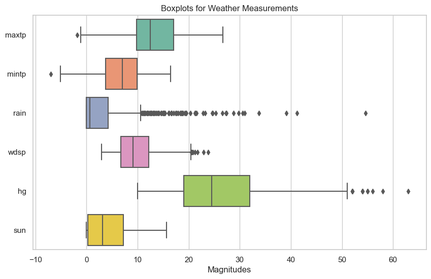

```python
sns.set(style="whitegrid")
plt.figure(figsize=(10, 6))
sns.boxplot(data=weather, orient="h", palette="Set2")#horizontally oriented

# Set labels for the boxplots
plt.xlabel("Magnitudes")
plt.title("Boxplots for Weather Measurements")

# Show the plot
plt.show()
```

#### Comparative Summary

After observing the numerical and graphical summaries for weather measurements at the given locations, we infer that:-

- All the airports have similar mean values of minimum temperature and maximum temperature in a day which suggests that the mean range of temperature in a day stays mostly stagnant.
- The temperature values fluctuate the most at Dublin airport in comparison with Shannon and Cork airport due to a greater standard deviation in temperature values at Dublin airport.
- Cork airport receives the highest mean rainfall followed by Shannon and Dublin airport.
- The rainfall varies the most at Cork airport due to a greater standard deviation value than its counterparts(Shannon airport,Dublin airport) where the variability in rainfall is almost similar.
- The average windspeed and highest gust at Cork airport is slightly greater than its counterparts(Shannon airport,Dublin airport) where the mean windspeed is almost similar
- The windspeed varies the most at Shannon Airport and windspeed variations at Cork and Dublin airport is almost similar.
- Cork Airport receives the highest average sunlight duration followed by Dublin Airport and Shannon Airport.
- The sunlight duration fluctuates the most at Cork airport followed by Dublin airport and Shannon airport.
- By looking at the histograms of distribution for various weather measurements and different airports we can conclude that the weather at the given locations is similar enough and there is not sufficient evidence(in the given dataset) to prove otherwise.